# Minimalizacja stochastyczna - porównanie algorytmów

2025-01-30  
Robert Raniszewski, Paweł Czajczyk

# Wstęp

Projekt polega na prostym opracowaniu statystycznym wyników porównania działania wybranych algorytmów minimalizacji stochastycznej. Zaimplementowaliśmy algorytmy **PRS** oraz **GA**. Do porównania wybraliśmy funkcje **Alpine01** i **Schwefel**.

# Przedstawienie funkcji

## Alpine01

Funkcja **Alpine01** jest funkcją testową wykorzystywaną w optymalizacji, szczególnie w badaniach nad algorytmami optymalizacji globalnej. Charakteryzuje się wieloma lokalnymi minimami, co sprawia, że jest trudna do optymalizacji. Funkcja jest zdefiniowana jako:

$$f(x) = \sum_{i=1}^{d} \left( |x_i \sin(x_i) + 0.1 x_i| \right)$$

gdzie:  
- $x_i$ to elementy wektora zmiennych wejściowych,  
- $d$ to liczba wymiarów funkcji (liczba zmiennych wejściowych),  
- funkcja jest zwykle testowana w zakresie $x_i \in [-10, 10]$.

#### Cechy funkcji:

- **Globalne minimum**: Funkcja ma globalne minimum w punkcie $x = 0$ (dla wszystkich zmiennych $x_i = 0$).
- **Lokalne minima**: Funkcja ma wiele lokalnych minimów, co czyni ją wymagającą w testowaniu algorytmów optymalizacji.
- **Nieliniowość**: Funkcja jest nieliniowa, co sprawia, że jej analiza i optymalizacja stanowią wyzwanie.

## Funkcja Schwefela

gdzie:  
- $x_i$ to elementy wektora zmiennych wejściowych,  
- $d$ to liczba wymiarów funkcji,  
- funkcja jest zwykle testowana w zakresie $x_i \in [-500, 500]$.

#### Cechy funkcji:

- **Globalne minimum**: Funkcja osiąga swoje globalne minimum w punkcie $x = 420.9687$ (gdzie $x_i = 420.9687$ dla wszystkich $i$).
- **Lokalne minima**: Funkcja ma wiele lokalnych minimów, co czyni ją wyzwaniem dla algorytmów optymalizacji globalnej.
- **Nieliniowość i trudność**: Funkcja jest nieliniowa i wykazuje skomplikowaną strukturę, pełną zagięć i oscylacji, przez co jest trudna do optymalizacji.

# Analiza

W analizie zostały użyte następujące kroki:  
1. Przeprowadzenie obliczeń na danych wejściowych.  
2. Obliczenie średnich wartości oraz różnic między różnymi miarami.  
3. Wizualizacja wyników.

# Kod źródłowy

Korzystamy z bibliotek oraz ustawiamy seed dla powtarzalności testów:

```r
library(smoof)
library(ecr)
library(ggplot2)
library(kableExtra)
library(ParamHelpers) # Nowa zależność

set.seed(420)
```

Pobieramy dziedziny funkcji oraz generujemy losowe punkty:

```r
# 1. Pobieranie prawdziwych dziedzin ---------------------------------------------------------
get_domain <- function(fn) {
ps <- getParamSet(fn)
list(
lower = sapply(ps$pars, function(p) p$lower),
upper = sapply(ps$pars, function(p) p$upper)
)
}

# 2. Poprawiona funkcja generująca punkty ----------------------------------------------------
getRandomPoint <- function(dimensions, domain) {
sapply(1:dimensions, function(i) {
runif(1, domain$lower[i], domain$upper[i])
})
}
```

Implementujemy algorytmy PRS i GA:

```r
# 3. Uniwersalna funkcja PRS -----------------------------------------------------------------
performPRS <- function(n_eval, fn, domain) {
  dimensions <- length(domain$lower)
  points <- matrix(nrow = n_eval, ncol = dimensions)
  for(i in 1:n_eval) {
    points[i,] <- getRandomPoint(dimensions, domain)
  }
  min(apply(points, 1, fn))
}

# 4. Uniwersalna funkcja GA ------------------------------------------------------------------
performGA <- function(n_runs, n_eval, fn, domain) {
  dimensions <- length(domain$lower)
  res <- replicate(n_runs, ecr(
    fitness.fun = fn,
    n.dim = dimensions,
    lower = domain$lower,
    upper = domain$upper,
    minimize = TRUE,
    representation = "float",
    mu = 50L,
    lambda = 25L,
    terminators = list(stopOnEvals(n_eval)),
    mutator = setup(mutGauss, lower = domain$lower, upper = domain$upper)
  )$best.y)
  res
}
```

Tworzymy funkcję przeprowadzającą badania:

```r
run_experiment <- function(fn_name, dimensions, n_runs = 100) {
  # Inicjalizacja funkcji
  fn <- switch(fn_name,
               "Alpine01" = makeAlpine01Function(dimensions),
               "Schwefel" = makeSchwefelFunction(dimensions))

  domain <- get_domain(fn)
  true_min <- ifelse(fn_name == "Alpine01", 0, -418.9829 * dimensions)

  # PRS
  prs_results <- replicate(n_runs, performPRS(1000, fn, domain))

  # GA
  ga_results <- performGA(n_runs, 1000, fn, domain)

  list(
    prs = prs_results,
    ga = ga_results,
    stats = data.frame(
      Function = fn_name,
      Dimensions = dimensions,
      PRS_mean = mean(prs_results),
      GA_mean = mean(ga_results),
      True_min = true_min
    )
  )
}
```

Przeprowadzenie badań:

```r
results <- list(
  run_experiment("Alpine01", 2),
  run_experiment("Alpine01", 10),
  run_experiment("Alpine01", 20),
  run_experiment("Schwefel", 2),
  run_experiment("Schwefel", 10),
  run_experiment("Schwefel", 20)
)
```

#Wizualizacja Funkcje do wizualizacji wyników:

```r
visualize_histogram <- function(data, true_min) {
  ggplot(data, aes(x = value, fill = algorithm)) +
    geom_histogram(position = "identity", alpha = 0.7, bins = 30) +
    geom_vline(xintercept = true_min, color = "red", linetype = "dashed") +
    facet_wrap(~algorithm, ncol = 1) +
    labs(title = paste("Histogram wyników dla", unique(data$function_dim)),
         x = "Wartość funkcji", y = "Częstotliwość") +
    theme_bw()
}

visualize_violin <- function(data, true_min) {
  ggplot(data, aes(x = algorithm, y = value, fill = algorithm)) +
    geom_violin(trim = FALSE, show.legend = FALSE) +
    geom_boxplot(width = 0.1, fill = "white", outlier.size = 1) +
    geom_hline(yintercept = true_min, color = "red", linetype = "dashed") +
    labs(title = paste("Wykres skrzypcowy dla", unique(data$function_dim)),
         x = "Algorytm", y = "Wartość funkcji") +
    theme_bw() +
    theme(legend.position = "none")
}
```

Generowanie wykresów (czerwoną linią przerywaną oznaczyliśmy faktyczne minimum globalne funkcji):

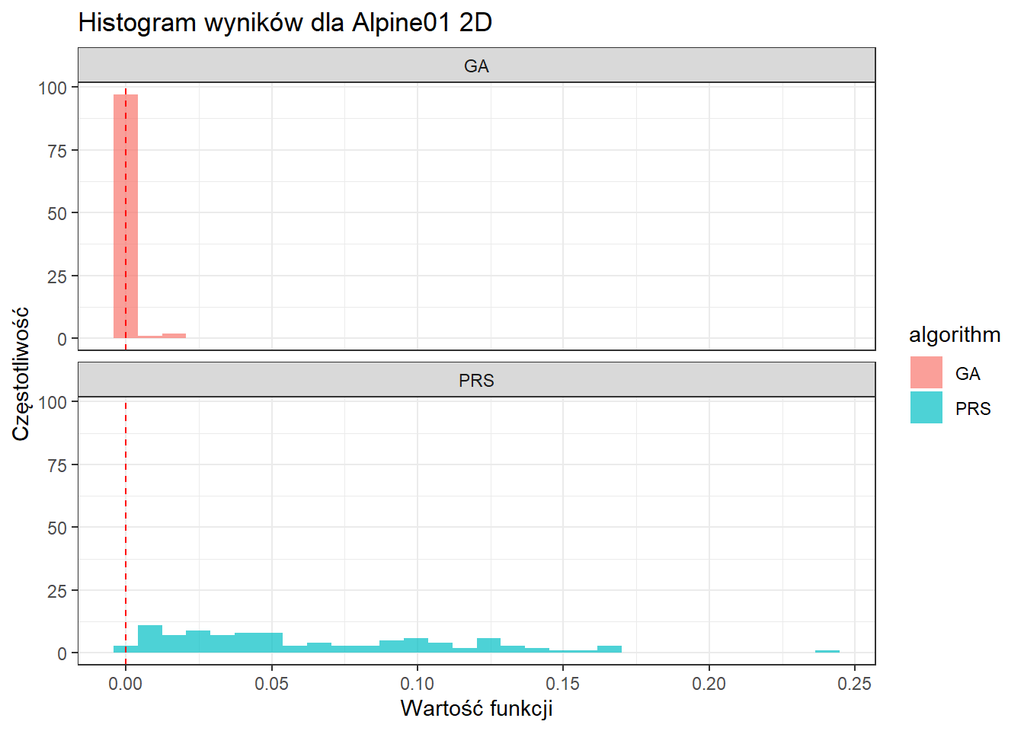

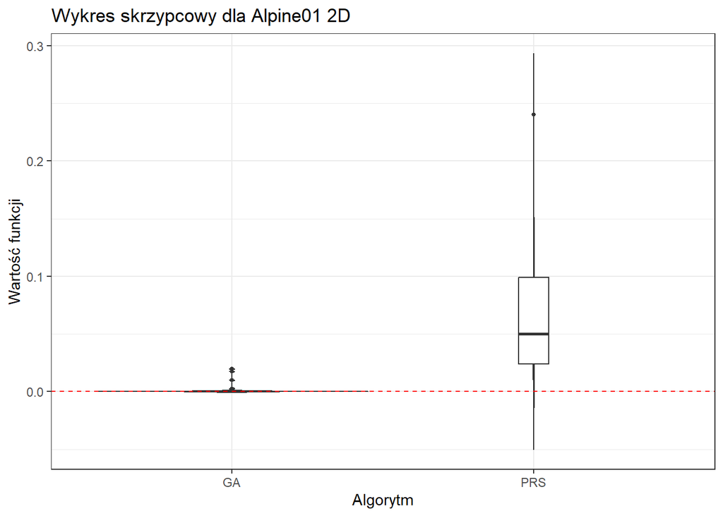

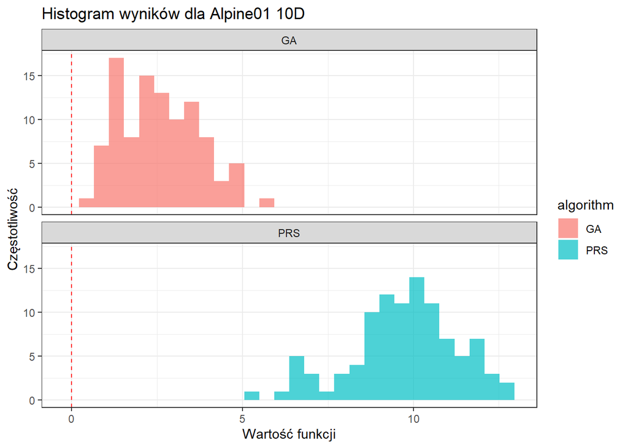

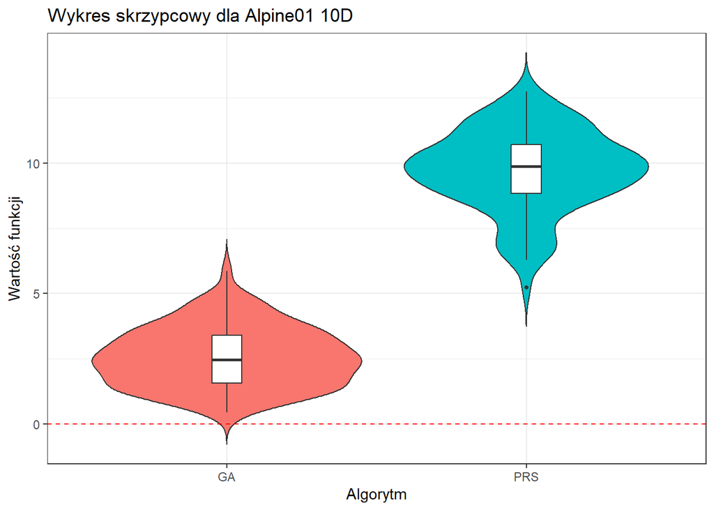

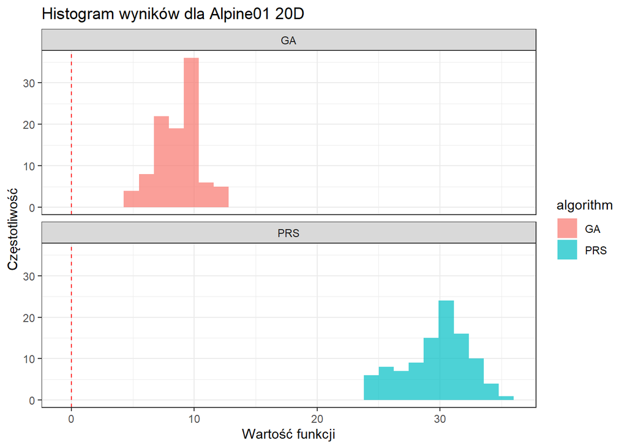

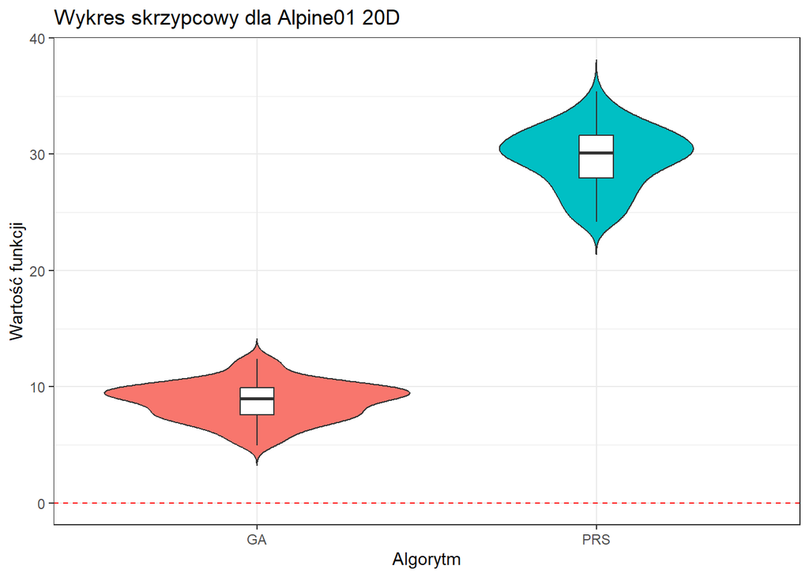

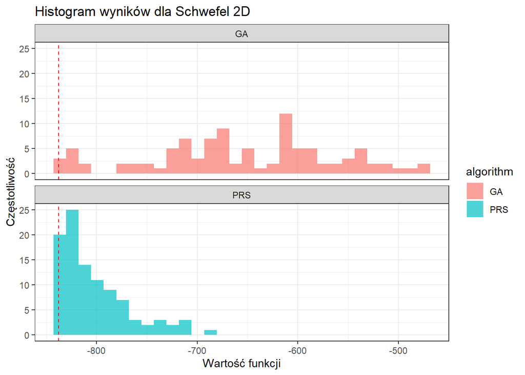

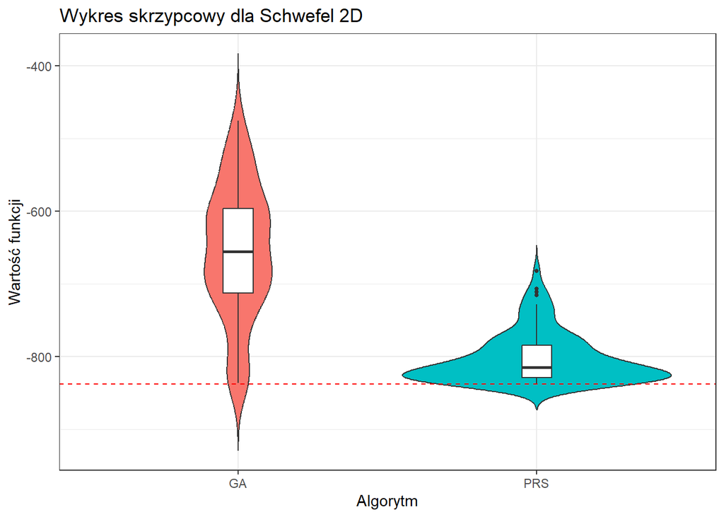

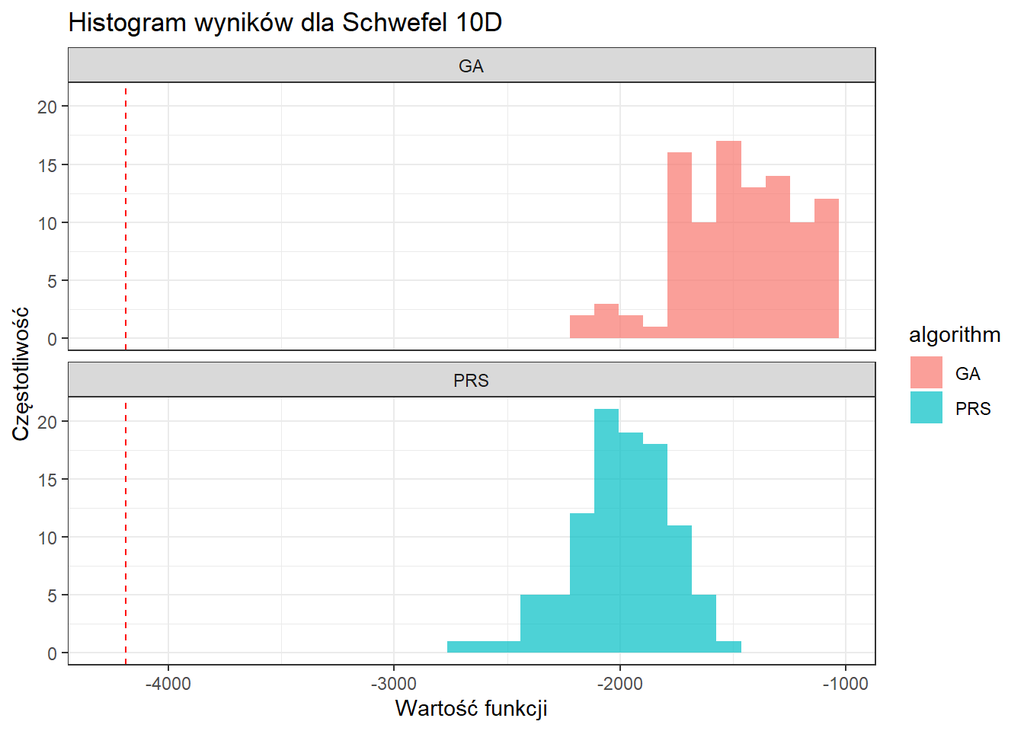

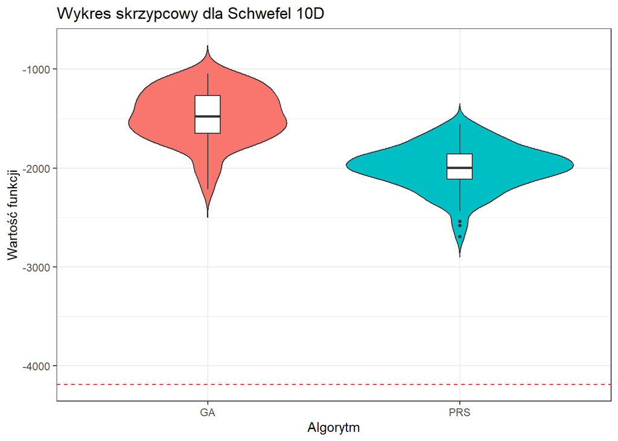

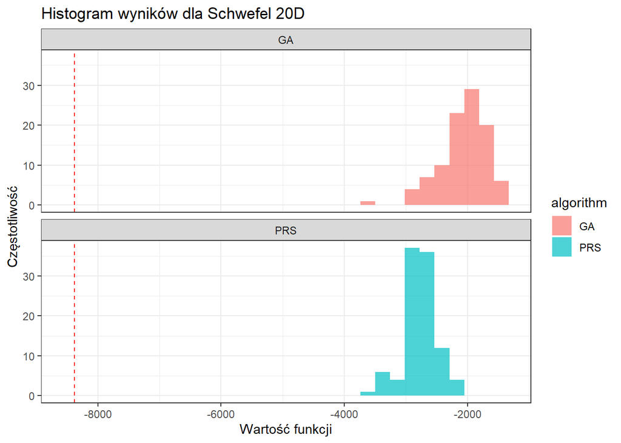

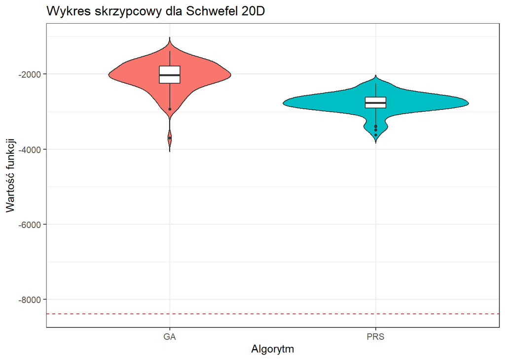

```r
for(res in results) {
  fn_dim <- paste0(res$stats$Function, " ", res$stats$Dimensions, "D")
  df <- data.frame(
    function_dim = fn_dim,
    algorithm = rep(c("PRS", "GA"), each = length(res$prs)),
    value = c(res$prs, res$ga)
  )
  print(visualize_histogram(df, res$stats$True_min))
  print(visualize_violin(df, res$stats$True_min))
}
```